# ltc_analysis

NL

15/06/2020

## Import and prepare the data

```r
library(skimr)

# Import the data
df <- read.csv("merged_LTC_odhf_quality.csv", na.strings="", header=TRUE)
skim(df)
```

Data summary

| Name | df |
| --- | --- |
| Number of rows | 615 |
| Number of columns | 49 |
| _______________________ |  |
| Column type frequency: |  |
| character | 6 |
| factor | 12 |
| numeric | 31 |
| ________________________ |  |
| Group variables | None |

**Variable type: character**

| skim_variable | n_missing | complete_rate | min | max | empty | n_unique | whitespace |
| --- | --- | --- | --- | --- | --- | --- | --- |
| name | 0 | 1 | 7 | 84 | 0 | 615 | 0 |
| cleaned_name | 0 | 1 | 7 | 84 | 0 | 615 | 0 |
| address | 0 | 1 | 8 | 61 | 0 | 614 | 0 |
| city | 0 | 1 | 3 | 19 | 0 | 263 | 0 |
| postal_code | 0 | 1 | 7 | 7 | 0 | 594 | 615 |
| CSDname | 1 | 1 | 3 | 39 | 0 | 208 | 0 |

**Variable type: factor**

| skim_variable | n_missing | complete_rate | ordered | n_unique | top_counts |
| --- | --- | --- | --- | --- | --- |
| LHIN | 0 | 1.00 | FALSE | 14 | Ham: 85, Sou: 76, Cen: 68, Cha: 57 |
| home_type | 0 | 1.00 | FALSE | 3 | For: 351, Non: 164, Mun: 100 |
| short_stay | 0 | 1.00 | FALSE | 2 | No: 412, Yes: 203 |
| residents_council | 0 | 1.00 | FALSE | 2 | Yes: 606, No: 9 |
| family_council | 0 | 1.00 | FALSE | 2 | Yes: 510, No: 105 |
| accreditation | 0 | 1.00 | FALSE | 2 | Yes: 511, No: 104 |
| confirmed_resident_cases | 486 | 0.21 | FALSE | 38 | <5: 48, 0: 36, 25: 3, 28: 3 |
| resident_deaths | 323 | 0.47 | FALSE | 36 | 0: 195, <5: 25, 11: 9, 18: 6 |
| confirmed_staff_cases | 486 | 0.21 | FALSE | 30 | <5: 53, 0: 24, 10: 4, 22: 4 |
| status | 323 | 0.47 | FALSE | 2 | Ina: 163, Act: 129 |
| outbreak | 0 | 1.00 | FALSE | 2 | no: 323, yes: 292 |
| region | 0 | 1.00 | FALSE | 5 | Wes: 233, Eas: 161, Cen: 122, Nor: 63 |

**Variable type: numeric**

| skim_variable | n_missing | complete_rate | mean | sd | p0 | p25 | p50 | p75 | p100 | hist |
| --- | --- | --- | --- | --- | --- | --- | --- | --- | --- | --- |
| total_inspections | 0 | 1 | 37.68 | 21.95 | 9.00 | 22.00 | 32.00 | 47.00 | 172.00 | ▇▃▁▁▁ |
| X5y_inspections | 0 | 1 | 19.82 | 11.95 | 5.00 | 12.00 | 17.00 | 24.00 | 86.00 | ▇▃▁▁▁ |
| X2y_inspections | 0 | 1 | 9.20 | 5.59 | 1.00 | 5.00 | 8.00 | 12.00 | 44.00 | ▇▅▁▁▁ |
| total_complaints | 0 | 1 | 14.70 | 11.64 | 0.00 | 7.00 | 12.00 | 20.00 | 94.00 | ▇▂▁▁▁ |
| X5y_complaints | 0 | 1 | 6.60 | 5.93 | 0.00 | 2.00 | 5.00 | 9.00 | 46.00 | ▇▂▁▁▁ |
| X2y_complaints | 0 | 1 | 3.20 | 2.86 | 0.00 | 1.00 | 3.00 | 5.00 | 20.00 | ▇▂▁▁▁ |
| total_critical | 0 | 1 | 12.61 | 9.17 | 0.00 | 6.50 | 11.00 | 16.00 | 62.00 | ▇▃▁▁▁ |
| X5y_critical | 0 | 1 | 6.54 | 4.82 | 0.00 | 3.00 | 5.00 | 8.00 | 40.00 | ▇▂▁▁▁ |
| X2y_critical | 0 | 1 | 3.98 | 2.54 | 0.00 | 2.00 | 3.00 | 5.00 | 26.00 | ▇▂▁▁▁ |
| total_withOrders | 0 | 1 | 6.88 | 6.17 | 0.00 | 3.00 | 5.00 | 9.00 | 43.00 | ▇▂▁▁▁ |
| X5y_withOrders | 0 | 1 | 4.41 | 4.35 | 0.00 | 2.00 | 3.00 | 6.00 | 34.00 | ▇▂▁▁▁ |
| X2y_withOrders | 0 | 1 | 1.85 | 2.20 | 0.00 | 0.00 | 1.00 | 3.00 | 16.00 | ▇▁▁▁▁ |
| antipsychotic_percent | 0 | 1 | 18.47 | 7.74 | 0.00 | 13.45 | 18.00 | 23.00 | 62.80 | ▃▇▂▁▁ |
| depression_percent | 0 | 1 | 23.40 | 10.09 | 1.50 | 15.25 | 23.40 | 31.40 | 48.40 | ▃▇▇▇▂ |
| falls_percent | 0 | 1 | 16.49 | 4.83 | 1.80 | 13.35 | 16.40 | 19.70 | 33.20 | ▁▅▇▂▁ |
| pressure_ulcers_percent | 0 | 1 | 2.74 | 1.53 | 0.00 | 1.60 | 2.60 | 3.60 | 11.00 | ▇▇▂▁▁ |
| pain_percent | 0 | 1 | 5.67 | 5.77 | 0.00 | 1.95 | 3.90 | 7.50 | 48.00 | ▇▂▁▁▁ |
| restraints_percent | 0 | 1 | 4.21 | 5.75 | 0.00 | 0.40 | 2.20 | 5.80 | 42.00 | ▇▁▁▁▁ |
| number_beds | 0 | 1 | 127.27 | 73.83 | 12.00 | 69.00 | 120.00 | 160.00 | 543.00 | ▇▇▁▁▁ |
| CSDuid | 2 | 1 | 3527707.51 | 14148.84 | 3501005.00 | 3520005.00 | 3525005.00 | 3539005.00 | 3560042.00 | ▃▇▅▅▂ |
| latitude | 1 | 1 | 44.20 | 1.47 | 42.03 | 43.32 | 43.76 | 44.55 | 51.01 | ▇▅▁▁▁ |
| longitude | 1 | 1 | -79.62 | 6.99 | -94.57 | -80.75 | -79.63 | -79.17 | 79.63 | ▇▁▁▁▁ |
| total_cc | 0 | 1 | 27.32 | 19.14 | 0.00 | 14.00 | 23.00 | 35.50 | 153.00 | ▇▃▁▁▁ |
| X5y_cc | 0 | 1 | 13.14 | 9.91 | 0.00 | 7.00 | 10.00 | 17.00 | 63.00 | ▇▅▁▁▁ |
| X2y_cc | 0 | 1 | 7.17 | 4.66 | 0.00 | 4.00 | 6.00 | 9.00 | 34.00 | ▇▆▁▁▁ |
| total_ccw | 0 | 1 | 34.20 | 22.68 | 2.00 | 18.00 | 28.00 | 44.00 | 165.00 | ▇▃▁▁▁ |
| X5y_ccw | 0 | 1 | 17.54 | 12.63 | 1.00 | 9.00 | 15.00 | 22.00 | 93.00 | ▇▃▁▁▁ |
| X2y_ccw | 0 | 1 | 9.02 | 6.00 | 0.00 | 5.00 | 8.00 | 12.00 | 45.00 | ▇▃▁▁▁ |
| total_noncomplaints | 0 | 1 | 22.98 | 12.09 | 5.00 | 15.00 | 20.00 | 28.00 | 90.00 | ▇▃▁▁▁ |
| X5y_noncomplaints | 0 | 1 | 13.23 | 7.11 | 4.00 | 9.00 | 11.00 | 15.00 | 68.00 | ▇▂▁▁▁ |
| X2y_noncomplaints | 0 | 1 | 6.00 | 3.64 | 0.00 | 4.00 | 5.00 | 8.00 | 40.00 | ▇▂▁▁▁ |

We see above that the inspections and number of beds data are highly right skewed with skewness values > 1. The quality data are not as right skewed with skewness values between 0 and 1, except for pain_percent which has a skewness value of 2.5.

The highly skewed variables will have to be transformed for the analysis, but first we explore the variables to assess for any zero values.

We see that the following variables contain zeros: - antipsychotic_percent - pressure_ulcers_percent - pain_percent - complaints group - critical group - withOrders group - cc group - X2y_noncomplaints - X2y_ccw

## Explore the variables for transformation

```r
# Create a list of numeric variables with 0 values
list0s <- c('antipsychotic_percent', 'pressure_ulcers_percent', 'pain_percent', complaints, 'X2y_noncomplaints', critical, withOrders, 'total_cc', 'X5y_cc', 'X2y_cc', 'X2y_ccw')

library(rcompanion)
listofcols <- setdiff(listofcols, list0s)

# Visualize the effect of square root and log transformations on the data without 0s
for (each in listofcols) {
  plotNormalHistogram(x = data[[each]], main = each)
  plotNormalHistogram(x = sqrt(data[[each]]), main = c(each, 'sqrt trans'))
  plotNormalHistogram(x = log(data[[each]]), main = c(each, 'log trans'))
}
```

[output not shown]

A square root transformation seems best for the following data: - number_beds

A log transformation seems better for the following data: - all_inspections group - total_noncomplaints - X5y_noncomplaints - total_ccw - X5y_ccw

```r
# Visualize the effect of a square root transformation on the variables with 0s
for (each in list0s) {
  plotNormalHistogram(x = data[[each]], main = each)
  plotNormalHistogram(x = sqrt(data[[each]]), main = c(each, 'sqrt trans'))
}
```

[output not shown]

## Transform the data

```r
# Log transform in place
data[c(all_inspections, 'total_noncomplaints', 'X5y_noncomplaints', 'total_ccw', 'X5y_ccw')] <- log(data[c(all_inspections, 'total_noncomplaints', 'X5y_noncomplaints', 'total_ccw', 'X5y_ccw')])

# Square root transform in place
data[c('number_beds', list0s)] <- sqrt(data[c('number_beds', list0s)])

skim(data)
```

Data summary

| Name | data |
| --- | --- |
| Number of rows | 615 |
| Number of columns | 34 |
| _______________________ |  |
| Column type frequency: |  |
| factor | 7 |
| numeric | 27 |
| ________________________ |  |
| Group variables | None |

**Variable type: factor**

| skim_variable | n_missing | complete_rate | ordered | n_unique | top_counts |
| --- | --- | --- | --- | --- | --- |
| outbreak | 0 | 1 | FALSE | 2 | no: 323, yes: 292 |
| home_type | 0 | 1 | FALSE | 3 | For: 351, Non: 164, Mun: 100 |
| short_stay | 0 | 1 | FALSE | 2 | No: 412, Yes: 203 |
| residents_council | 0 | 1 | FALSE | 2 | Yes: 606, No: 9 |
| family_council | 0 | 1 | FALSE | 2 | Yes: 510, No: 105 |
| accreditation | 0 | 1 | FALSE | 2 | Yes: 511, No: 104 |
| region | 0 | 1 | FALSE | 5 | Wes: 233, Eas: 161, Cen: 122, Nor: 63 |

**Variable type: numeric**

| skim_variable | n_missing | complete_rate | mean | sd | p0 | p25 | p50 | p75 | p100 | hist |
| --- | --- | --- | --- | --- | --- | --- | --- | --- | --- | --- |
| number_beds | 0 | 1 | 10.84 | 3.13 | 3.46 | 8.31 | 10.95 | 12.65 | 23.30 | ▂▇▅▁▁ |
| antipsychotic_percent | 0 | 1 | 4.19 | 0.94 | 0.00 | 3.67 | 4.24 | 4.80 | 7.92 | ▁▂▇▃▁ |
| depression_percent | 0 | 1 | 23.40 | 10.09 | 1.50 | 15.25 | 23.40 | 31.40 | 48.40 | ▃▇▇▇▂ |
| falls_percent | 0 | 1 | 16.49 | 4.83 | 1.80 | 13.35 | 16.40 | 19.70 | 33.20 | ▁▅▇▂▁ |
| pressure_ulcers_percent | 0 | 1 | 1.58 | 0.50 | 0.00 | 1.26 | 1.61 | 1.90 | 3.32 | ▁▃▇▃▁ |
| pain_percent | 0 | 1 | 2.13 | 1.07 | 0.00 | 1.40 | 1.97 | 2.74 | 6.93 | ▃▇▃▁▁ |
| total_inspections | 0 | 1 | 3.48 | 0.54 | 2.20 | 3.09 | 3.47 | 3.85 | 5.15 | ▂▇▇▃▁ |
| X5y_inspections | 0 | 1 | 2.84 | 0.52 | 1.61 | 2.48 | 2.83 | 3.18 | 4.45 | ▂▇▇▃▁ |
| X2y_inspections | 0 | 1 | 2.06 | 0.56 | 0.00 | 1.61 | 2.08 | 2.48 | 3.78 | ▁▂▇▆▁ |
| total_complaints | 0 | 1 | 3.55 | 1.44 | 0.00 | 2.65 | 3.46 | 4.47 | 9.70 | ▂▇▅▁▁ |
| X5y_complaints | 0 | 1 | 2.31 | 1.12 | 0.00 | 1.41 | 2.24 | 3.00 | 6.78 | ▂▇▃▁▁ |
| X2y_complaints | 0 | 1 | 1.57 | 0.86 | 0.00 | 1.00 | 1.73 | 2.24 | 4.47 | ▂▇▅▁▁ |
| total_critical | 0 | 1 | 3.35 | 1.19 | 0.00 | 2.55 | 3.32 | 4.00 | 7.87 | ▁▇▇▂▁ |
| X5y_critical | 0 | 1 | 2.41 | 0.85 | 0.00 | 1.73 | 2.24 | 2.83 | 6.32 | ▁▇▅▁▁ |
| X2y_critical | 0 | 1 | 1.90 | 0.61 | 0.00 | 1.41 | 1.73 | 2.24 | 5.10 | ▂▇▃▁▁ |
| total_noncomplaints | 0 | 1 | 3.02 | 0.47 | 1.61 | 2.71 | 3.00 | 3.33 | 4.50 | ▁▅▇▃▁ |
| X5y_noncomplaints | 0 | 1 | 2.47 | 0.45 | 1.39 | 2.20 | 2.40 | 2.71 | 4.22 | ▂▇▆▂▁ |
| X2y_noncomplaints | 0 | 1 | 2.36 | 0.67 | 0.00 | 2.00 | 2.24 | 2.83 | 6.32 | ▁▇▅▁▁ |
| total_withOrders | 0 | 1 | 2.37 | 1.12 | 0.00 | 1.73 | 2.24 | 3.00 | 6.56 | ▂▇▅▁▁ |
| X5y_withOrders | 0 | 1 | 1.84 | 1.00 | 0.00 | 1.41 | 1.73 | 2.45 | 5.83 | ▅▇▅▁▁ |
| X2y_withOrders | 0 | 1 | 1.06 | 0.85 | 0.00 | 0.00 | 1.00 | 1.73 | 4.00 | ▆▇▃▁▁ |
| total_cc | 0 | 1 | 4.94 | 1.70 | 0.00 | 3.74 | 4.80 | 5.96 | 12.37 | ▁▇▆▁▁ |
| X5y_cc | 0 | 1 | 3.41 | 1.24 | 0.00 | 2.65 | 3.16 | 4.12 | 7.94 | ▁▇▆▂▁ |
| X2y_cc | 0 | 1 | 2.55 | 0.82 | 0.00 | 2.00 | 2.45 | 3.00 | 5.83 | ▁▇▇▂▁ |
| total_ccw | 0 | 1 | 3.32 | 0.67 | 0.69 | 2.89 | 3.33 | 3.78 | 5.11 | ▁▂▇▇▂ |
| X5y_ccw | 0 | 1 | 2.64 | 0.69 | 0.00 | 2.20 | 2.71 | 3.09 | 4.53 | ▁▂▇▇▂ |
| X2y_ccw | 0 | 1 | 2.86 | 0.93 | 0.00 | 2.24 | 2.83 | 3.46 | 6.71 | ▁▇▇▂▁ |

```r
# Inspect the distribution of the categorical variables
xtabs(~outbreak + home_type, data=df)
```

```
##         home_type
## outbreak For-Profit Municipal Non-Profit
##      no         184        56         83
##      yes        167        44         81
```

```r
xtabs(~accreditation + home_type, data=df)
```

```
##              home_type
## accreditation For-Profit Municipal Non-Profit
##           No          25        29         50
##           Yes        326        71        114
```

```r
xtabs(~short_stay + home_type, data=df)
```

```
##           home_type
## short_stay For-Profit Municipal Non-Profit
##        No         248        53        111
##        Yes        103        47         53
```

```r
xtabs(~family_council + home_type, data=df)
```

```
##               home_type
## family_council For-Profit Municipal Non-Profit
##            No          65        10         30
##            Yes        286        90        134
```

```r
xtabs(~residents_council + home_type, data=df)
```

```
##                  home_type
## residents_council For-Profit Municipal Non-Profit
##               No           5         0          4
##               Yes        346       100        160
```

```r
xtabs(~residents_council + outbreak, data=df)
```

```
##                  outbreak
## residents_council  no yes
##               No    3   6
##               Yes 320 286
```

```r
xtabs(~accreditation + outbreak, data=df)
```

```
##              outbreak
## accreditation  no yes
##           No   62  42
##           Yes 261 250
```

```r
xtabs(~short_stay + outbreak, data=df)
```

```
##           outbreak
## short_stay  no yes
##        No  219 193
##        Yes 104  99
```

```r
xtabs(~family_council + outbreak, data=df)
```

```
##               outbreak
## family_council  no yes
##            No   68  37
##            Yes 255 255
```

```r
xtabs(~family_council + residents_council, data=df)
```

```
##               residents_council
## family_council  No Yes
##            No    5 100
##            Yes   4 506
```

## Fit logistic regression

```r
# Fit logistic regression using transformed data
fit = glm(outbreak~., family=binomial, data=data)
summary(fit)
```

```
##
## Call:
## glm(formula = outbreak ~ ., family = binomial, data = data)
##
## Deviance Residuals:
##     Min       1Q   Median       3Q      Max
## -2.2487  -0.9295  -0.4374   0.9504   2.1831
##
## Coefficients:
##                          Estimate Std. Error z value Pr(>|z|)
## (Intercept)              3.143193   2.840671   1.106   0.2685
## home_typeMunicipal      -0.533617   0.294532  -1.812   0.0700 .
## home_typeNon-Profit      0.048595   0.251397   0.193   0.8467
## number_beds              0.232655   0.050627   4.595 4.32e-06 ***
## short_stayYes           -0.181057   0.210418  -0.860   0.3895
## residents_councilYes    -0.521201   0.953494  -0.547   0.5846
## family_councilYes        0.157426   0.267084   0.589   0.5556
## accreditationYes        -0.236254   0.278384  -0.849   0.3961
## regionEast              -0.237564   0.324196  -0.733   0.4637
## regionNorth             -0.946643   0.427283  -2.215   0.0267 *
## regionToronto            0.689524   0.484719   1.423   0.1549
## regionWest              -0.511712   0.290713  -1.760   0.0784 .
## antipsychotic_percent    0.124144   0.105996   1.171   0.2415
## depression_percent       0.005139   0.010747   0.478   0.6325
## falls_percent           -0.012270   0.021731  -0.565   0.5723
## pressure_ulcers_percent -0.012357   0.228484  -0.054   0.9569
## pain_percent            -0.128315   0.098233  -1.306   0.1915
## total_inspections       -7.622314   4.436957  -1.718   0.0858 .
## X5y_inspections          5.059650   3.793593   1.334   0.1823
## X2y_inspections         -1.082597   1.207296  -0.897   0.3699
## total_complaints         0.862600   0.978836   0.881   0.3782
## X5y_complaints           0.087526   0.839495   0.104   0.9170
## X2y_complaints          -0.267613   0.604419  -0.443   0.6579
## total_critical          -0.544059   1.194274  -0.456   0.6487
## X5y_critical             1.538881   1.340180   1.148   0.2509
## X2y_critical            -1.358774   0.965301  -1.408   0.1592
## total_noncomplaints      3.844665   2.718140   1.414   0.1572
## X5y_noncomplaints       -4.774187   2.600318  -1.836   0.0664 .
## X2y_noncomplaints        1.090983   0.776042   1.406   0.1598
## total_withOrders        -0.262043   0.346652  -0.756   0.4497
## X5y_withOrders           0.756159   0.394837   1.915   0.0555 .
## X2y_withOrders           0.135237   0.422691   0.320   0.7490
## total_cc                 0.717939   1.517787   0.473   0.6362
## X5y_cc                  -1.305044   1.571094  -0.831   0.4062
## X2y_cc                   2.055378   1.531700   1.342   0.1796
## total_ccw                1.548906   1.813860   0.854   0.3931
## X5y_ccw                 -0.942757   1.309266  -0.720   0.4715
## X2y_ccw                 -1.033641   1.096100  -0.943   0.3457
## ---
## Signif. codes:  0 '***' 0.001 '**' 0.01 '*' 0.05 '.' 0.1 ' ' 1
##
## (Dispersion parameter for binomial family taken to be 1)
##
##     Null deviance: 851.01  on 614  degrees of freedom
## Residual deviance: 695.67  on 577  degrees of freedom
## AIC: 771.67
##
## Number of Fisher Scoring iterations: 4
```

### Backwards selection

```r
# Backwards selection
summary(fit)
```

```
##
## Call:
## glm(formula = outbreak ~ number_beds + family_council + region +
##     total_complaints, family = binomial, data = data)
##
## Deviance Residuals:
##     Min       1Q   Median       3Q      Max
## -2.0172  -0.9768  -0.4551   1.0108   2.0083
##
## Coefficients:
##                   Estimate Std. Error z value Pr(>|z|)
## (Intercept)       -2.85512    0.46241  -6.174 6.64e-10 ***
## number_beds        0.19801    0.03993   4.959 7.07e-07 ***
## family_councilYes  0.10140    0.25050   0.405  0.68561
## regionEast        -0.50000    0.26405  -1.894  0.05828 .
## regionNorth       -1.03173    0.37660  -2.740  0.00615 **
## regionToronto      0.67297    0.45206   1.489  0.13657
## regionWest        -0.57752    0.25091  -2.302  0.02135 *
## total_complaints   0.25978    0.08097   3.208  0.00134 **
## ---
## Signif. codes:  0 '***' 0.001 '**' 0.01 '*' 0.05 '.' 0.1 ' ' 1
##
## (Dispersion parameter for binomial family taken to be 1)
##
##     Null deviance: 851.01  on 614  degrees of freedom
## Residual deviance: 729.86  on 607  degrees of freedom
## AIC: 745.86
##
## Number of Fisher Scoring iterations: 4
```

As shown when all variables are included in the initial regression and then backwards selection is used for variable selection, the significant variables are number of beds, total complaints and region.

```r
# Calculate McFadden's pseudo R2
ll.null <- fit$null.deviance/-2
ll.proposed <- fit$deviance/-2
print((ll.null - ll.proposed)/ll.null)
```

```
## [1] 0.1423571
```

```r
1 - pchisq(2*(ll.proposed - ll.null), df = (length(fit$coefficients)-1)) #pvalue
```

```
## [1] 0
```

## Visualize the model

```
## Note: As of version 1.0.0, cowplot does not change the
```

```
##   default ggplot2 theme anymore. To recover the previous
```

```
##   behavior, execute:
##   theme_set(theme_cowplot())
```

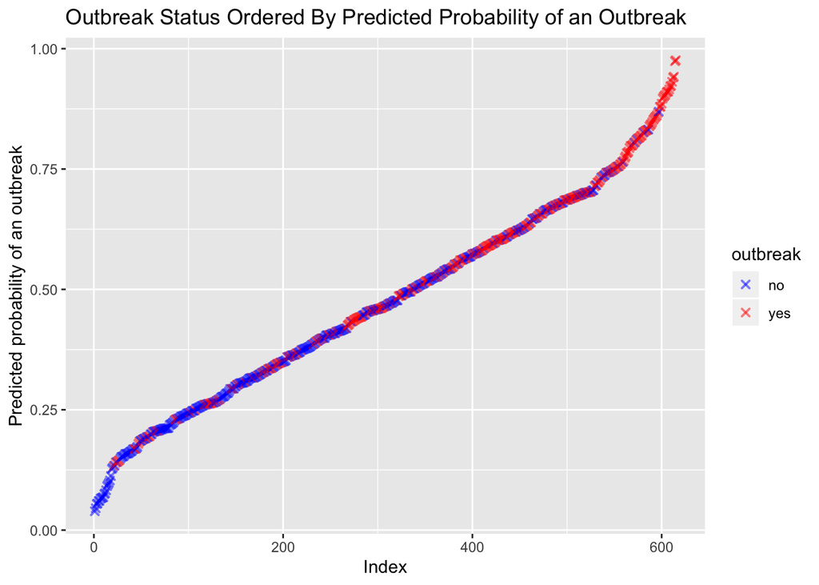

```r
# Repeat the logistic regression with selected variables
data_selected <- subset(df, select= c('outbreak', 'home_type', 'number_beds', noncomplaints, complaints, withOrders))
skim(data_selected)
```

Data summary

| Name | data_selected |
| --- | --- |
| Number of rows | 615 |
| Number of columns | 12 |
| _______________________ |  |
| Column type frequency: |  |
| factor | 2 |
| numeric | 10 |
| ________________________ |  |
| Group variables | None |

**Variable type: factor**

| skim_variable | n_missing | complete_rate | ordered | n_unique | top_counts |
| --- | --- | --- | --- | --- | --- |
| outbreak | 0 | 1 | FALSE | 2 | no: 323, yes: 292 |
| home_type | 0 | 1 | FALSE | 3 | For: 351, Non: 164, Mun: 100 |

**Variable type: numeric**

| skim_variable | n_missing | complete_rate | mean | sd | p0 | p25 | p50 | p75 | p100 | hist |
| --- | --- | --- | --- | --- | --- | --- | --- | --- | --- | --- |
| number_beds | 0 | 1 | 127.27 | 73.83 | 12 | 69 | 120 | 160 | 543 | ▇▇▁▁▁ |
| total_noncomplaints | 0 | 1 | 22.98 | 12.09 | 5 | 15 | 20 | 28 | 90 | ▇▃▁▁▁ |
| X5y_noncomplaints | 0 | 1 | 13.23 | 7.11 | 4 | 9 | 11 | 15 | 68 | ▇▂▁▁▁ |
| X2y_noncomplaints | 0 | 1 | 6.00 | 3.64 | 0 | 4 | 5 | 8 | 40 | ▇▂▁▁▁ |
| total_complaints | 0 | 1 | 14.70 | 11.64 | 0 | 7 | 12 | 20 | 94 | ▇▂▁▁▁ |
| X5y_complaints | 0 | 1 | 6.60 | 5.93 | 0 | 2 | 5 | 9 | 46 | ▇▂▁▁▁ |
| X2y_complaints | 0 | 1 | 3.20 | 2.86 | 0 | 1 | 3 | 5 | 20 | ▇▂▁▁▁ |
| total_withOrders | 0 | 1 | 6.88 | 6.17 | 0 | 3 | 5 | 9 | 43 | ▇▂▁▁▁ |
| X5y_withOrders | 0 | 1 | 4.41 | 4.35 | 0 | 2 | 3 | 6 | 34 | ▇▂▁▁▁ |
| X2y_withOrders | 0 | 1 | 1.85 | 2.20 | 0 | 0 | 1 | 3 | 16 | ▇▁▁▁▁ |

```r
fit = glm(outbreak~., family=binomial, data=data_selected)
summary(fit)
```

```
##
## Call:
## glm(formula = outbreak ~ ., family = binomial, data = data_selected)
##
## Deviance Residuals:
##     Min       1Q   Median       3Q      Max
## -2.4042  -0.9564  -0.6169   1.0565   1.9789
##
## Coefficients:
##                      Estimate Std. Error z value Pr(>|z|)
## (Intercept)         -1.552933   0.267264  -5.810 6.23e-09 ***
## home_typeMunicipal  -0.551167   0.270037  -2.041   0.0412 *
## home_typeNon-Profit  0.155759   0.216670   0.719   0.4722
## number_beds          0.011545   0.001887   6.119 9.42e-10 ***
## total_noncomplaints -0.018206   0.019458  -0.936   0.3495
## X5y_noncomplaints   -0.036013   0.043604  -0.826   0.4089
## X2y_noncomplaints    0.021829   0.062826   0.347   0.7282
## total_complaints     0.036504   0.020229   1.805   0.0711 .
## X5y_complaints       0.015913   0.047024   0.338   0.7351
## X2y_complaints       0.019416   0.062150   0.312   0.7547
## total_withOrders    -0.027825   0.039733  -0.700   0.4837
## X5y_withOrders       0.083603   0.075386   1.109   0.2674
## X2y_withOrders      -0.024768   0.095839  -0.258   0.7961
## ---
## Signif. codes:  0 '***' 0.001 '**' 0.01 '*' 0.05 '.' 0.1 ' ' 1
##
## (Dispersion parameter for binomial family taken to be 1)
##
##     Null deviance: 851.01  on 614  degrees of freedom
## Residual deviance: 730.55  on 602  degrees of freedom
## AIC: 756.55
##
## Number of Fisher Scoring iterations: 4
```

```r
# Backwards Selection
summary(fit)
```

```
##
## Call:
## glm(formula = outbreak ~ home_type + number_beds + total_noncomplaints +
##     total_complaints, family = binomial, data = data_selected)
##
## Deviance Residuals:
##     Min       1Q   Median       3Q      Max
## -2.5854  -0.9661  -0.6290   1.0365   1.9760
##
## Coefficients:
##                     Estimate Std. Error z value Pr(>|z|)
## (Intercept)         -1.60829    0.25716  -6.254 4.00e-10 ***
## home_typeMunicipal  -0.56603    0.26722  -2.118  0.03416 *
## home_typeNon-Profit  0.16650    0.21424   0.777  0.43707
## number_beds          0.01174    0.00183   6.415 1.41e-10 ***
## total_noncomplaints -0.02500    0.01113  -2.246  0.02468 *
## total_complaints     0.04584    0.01344   3.410  0.00065 ***
## ---
## Signif. codes:  0 '***' 0.001 '**' 0.01 '*' 0.05 '.' 0.1 ' ' 1
##
## (Dispersion parameter for binomial family taken to be 1)
##
##     Null deviance: 851.01  on 614  degrees of freedom
## Residual deviance: 733.42  on 609  degrees of freedom
## AIC: 745.42
##
## Number of Fisher Scoring iterations: 4
```

```r
### Repeat the logistic regression with selected variables
data_selected <- subset(df, select= c('outbreak', 'home_type', 'number_beds', all_inspections, complaints, withOrders))
skim(data_selected)
```

Data summary

| Name | data_selected |
| --- | --- |
| Number of rows | 615 |
| Number of columns | 12 |
| _______________________ |  |
| Column type frequency: |  |
| factor | 2 |
| numeric | 10 |
| ________________________ |  |
| Group variables | None |

**Variable type: factor**

| skim_variable | n_missing | complete_rate | ordered | n_unique | top_counts |
| --- | --- | --- | --- | --- | --- |
| outbreak | 0 | 1 | FALSE | 2 | no: 323, yes: 292 |
| home_type | 0 | 1 | FALSE | 3 | For: 351, Non: 164, Mun: 100 |

**Variable type: numeric**

| skim_variable | n_missing | complete_rate | mean | sd | p0 | p25 | p50 | p75 | p100 | hist |
| --- | --- | --- | --- | --- | --- | --- | --- | --- | --- | --- |
| number_beds | 0 | 1 | 127.27 | 73.83 | 12 | 69 | 120 | 160 | 543 | ▇▇▁▁▁ |
| total_inspections | 0 | 1 | 37.68 | 21.95 | 9 | 22 | 32 | 47 | 172 | ▇▃▁▁▁ |
| X5y_inspections | 0 | 1 | 19.82 | 11.95 | 5 | 12 | 17 | 24 | 86 | ▇▃▁▁▁ |
| X2y_inspections | 0 | 1 | 9.20 | 5.59 | 1 | 5 | 8 | 12 | 44 | ▇▅▁▁▁ |
| total_complaints | 0 | 1 | 14.70 | 11.64 | 0 | 7 | 12 | 20 | 94 | ▇▂▁▁▁ |
| X5y_complaints | 0 | 1 | 6.60 | 5.93 | 0 | 2 | 5 | 9 | 46 | ▇▂▁▁▁ |
| X2y_complaints | 0 | 1 | 3.20 | 2.86 | 0 | 1 | 3 | 5 | 20 | ▇▂▁▁▁ |
| total_withOrders | 0 | 1 | 6.88 | 6.17 | 0 | 3 | 5 | 9 | 43 | ▇▂▁▁▁ |
| X5y_withOrders | 0 | 1 | 4.41 | 4.35 | 0 | 2 | 3 | 6 | 34 | ▇▂▁▁▁ |
| X2y_withOrders | 0 | 1 | 1.85 | 2.20 | 0 | 0 | 1 | 3 | 16 | ▇▁▁▁▁ |

```r
fit = glm(outbreak~., family=binomial, data=data_selected)
summary(fit)
```

```
##
## Call:
## glm(formula = outbreak ~ ., family = binomial, data = data_selected)
##
## Deviance Residuals:
##     Min       1Q   Median       3Q      Max
## -2.4042  -0.9564  -0.6169   1.0565   1.9789
##
## Coefficients:
##                      Estimate Std. Error z value Pr(>|z|)
## (Intercept)         -1.552933   0.267264  -5.810 6.23e-09 ***
## home_typeMunicipal  -0.551167   0.270037  -2.041   0.0412 *
## home_typeNon-Profit  0.155759   0.216670   0.719   0.4722
## number_beds          0.011545   0.001887   6.119 9.42e-10 ***
## total_inspections   -0.018206   0.019458  -0.936   0.3495
## X5y_inspections     -0.036013   0.043604  -0.826   0.4089
## X2y_inspections      0.021829   0.062826   0.347   0.7282
## total_complaints     0.054710   0.032437   1.687   0.0917 .
## X5y_complaints       0.051926   0.073004   0.711   0.4769
## X2y_complaints      -0.002413   0.093847  -0.026   0.9795
## total_withOrders    -0.027825   0.039733  -0.700   0.4837
## X5y_withOrders       0.083603   0.075386   1.109   0.2674
## X2y_withOrders      -0.024768   0.095839  -0.258   0.7961
## ---
## Signif. codes:  0 '***' 0.001 '**' 0.01 '*' 0.05 '.' 0.1 ' ' 1
##
## (Dispersion parameter for binomial family taken to be 1)
##
##     Null deviance: 851.01  on 614  degrees of freedom
## Residual deviance: 730.55  on 602  degrees of freedom
## AIC: 756.55
##
## Number of Fisher Scoring iterations: 4
```

```r
# Backwards Selection
summary(fit)
```

```
##
## Call:
## glm(formula = outbreak ~ home_type + number_beds + total_inspections +
##     total_complaints, family = binomial, data = data_selected)
##
## Deviance Residuals:
##     Min       1Q   Median       3Q      Max
## -2.5854  -0.9661  -0.6290   1.0365   1.9760
##
## Coefficients:
##                     Estimate Std. Error z value Pr(>|z|)
## (Intercept)         -1.60829    0.25716  -6.254 4.00e-10 ***
## home_typeMunicipal  -0.56603    0.26722  -2.118  0.03416 *
## home_typeNon-Profit  0.16650    0.21424   0.777  0.43707
## number_beds          0.01174    0.00183   6.415 1.41e-10 ***
## total_inspections   -0.02500    0.01113  -2.246  0.02468 *
## total_complaints     0.07084    0.02235   3.170  0.00153 **
## ---
## Signif. codes:  0 '***' 0.001 '**' 0.01 '*' 0.05 '.' 0.1 ' ' 1
##
## (Dispersion parameter for binomial family taken to be 1)
##
##     Null deviance: 851.01  on 614  degrees of freedom
## Residual deviance: 733.42  on 609  degrees of freedom
## AIC: 745.42
##
## Number of Fisher Scoring iterations: 4
```